# ETC5521: Diving Deeply into Data Exploration

## Simpson’s paradox: famous example (1/2)

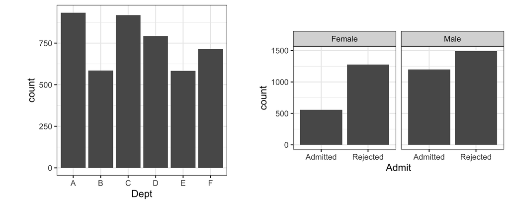

Did Berkeley discriminate against female applicants?

Example from Unwin (2015)

## Simpson’s paradox: famous example (2/2)

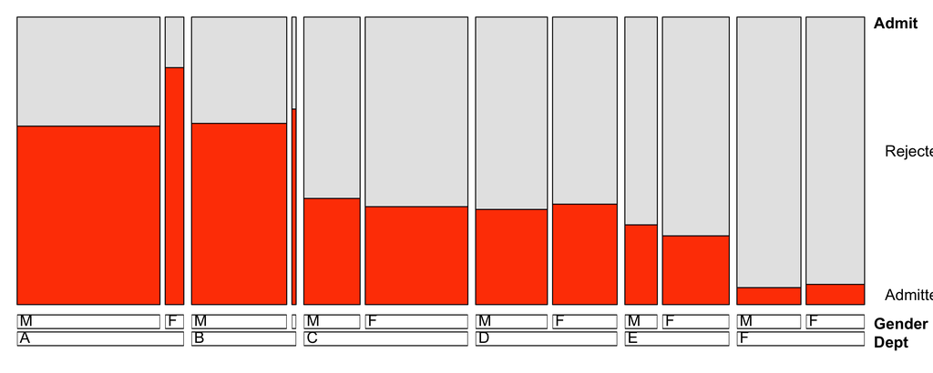

Based on separately examining each department, there is no evidence of discrimination against female applicants.

Example from Unwin (2015)

## Always examine the associations in each strata

## Handling and imputing missings (1/2)

Check if missings on one variable are related to distribution of the other variable.

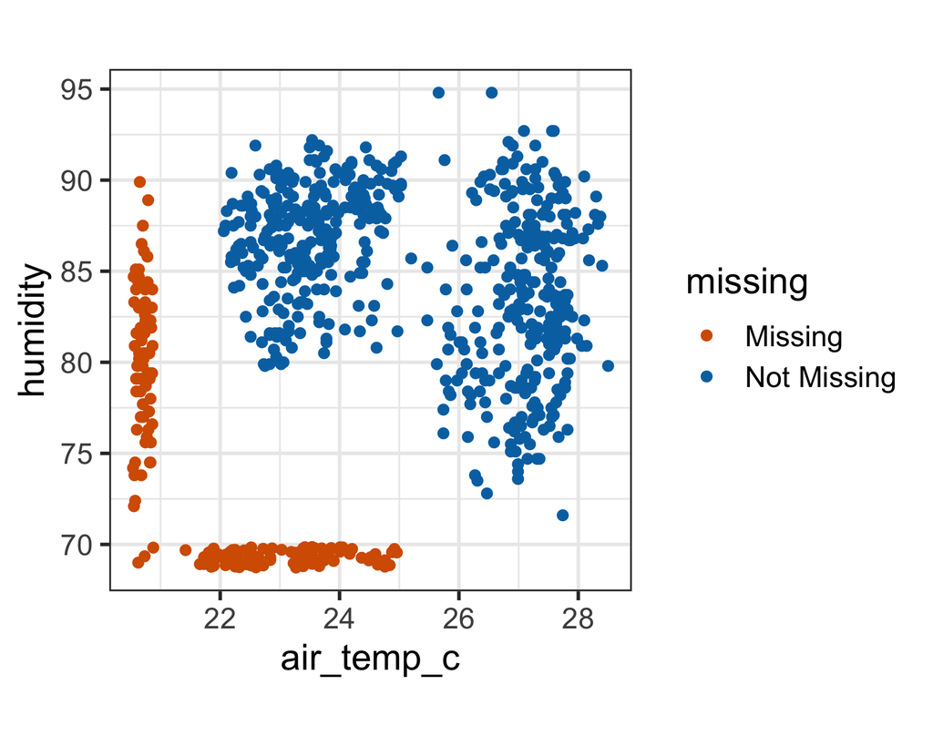

```r
ggplot(oceanbuoys,
       aes(x = air_temp_c,
           y = humidity)) +
     geom_miss_point()
```

- Missings plotted in the margins.
- Missings on humidity only occur for lower values of air tempoerature.

Imputing missings, at least for humidity requires using air temperature values.

But the clustering is due to year

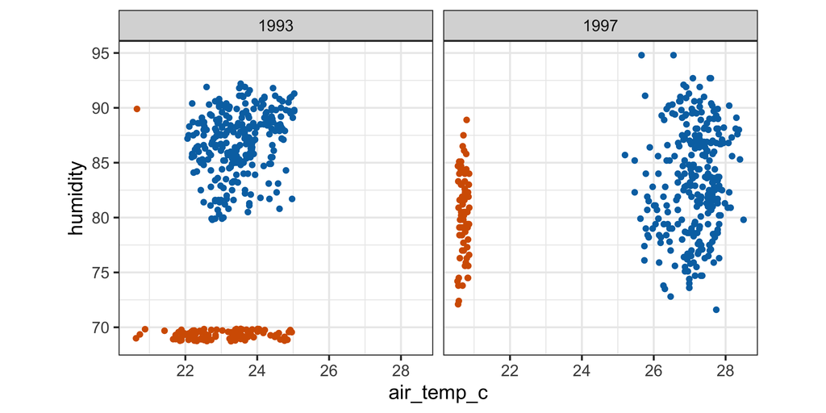

```r
ggplot(oceanbuoys,
       aes(x = air_temp_c,
           y = humidity)) +
     geom_miss_point() +
     facet_wrap(~year, ncol=2) +
     theme(legend.position = "none")
```

## Handling and imputing missings (2/2)

Use the mean of complete cases to impute the missings

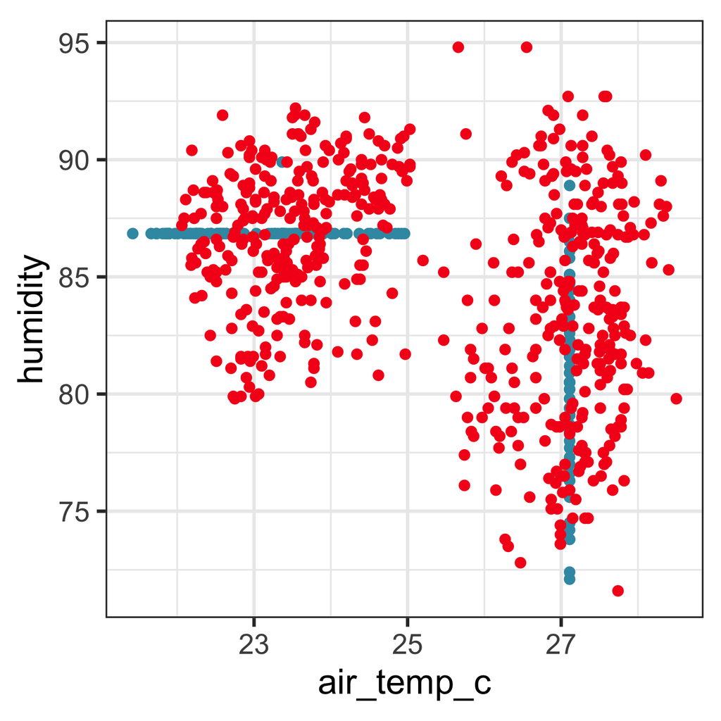

```r
ocean_imp_yr_mean <- oceanbuoys |>
  select(air_temp_c, humidity, year) |>
  bind_shadow() |>
  group_by(year) |>
  impute_mean_at(vars(air_temp_c, humidity)) |>
  ungroup() |>
  add_label_shadow()

ggplot(ocean_imp_yr_mean,
       aes(x = air_temp_c,
           y = humidity,
           colour = any_missing)) +
  geom_miss_point() +
  scale_color_discrete_divergingx(palette = "Zissou 1") +
  theme(legend.title = element_blank(),
        legend.position = "none")
```

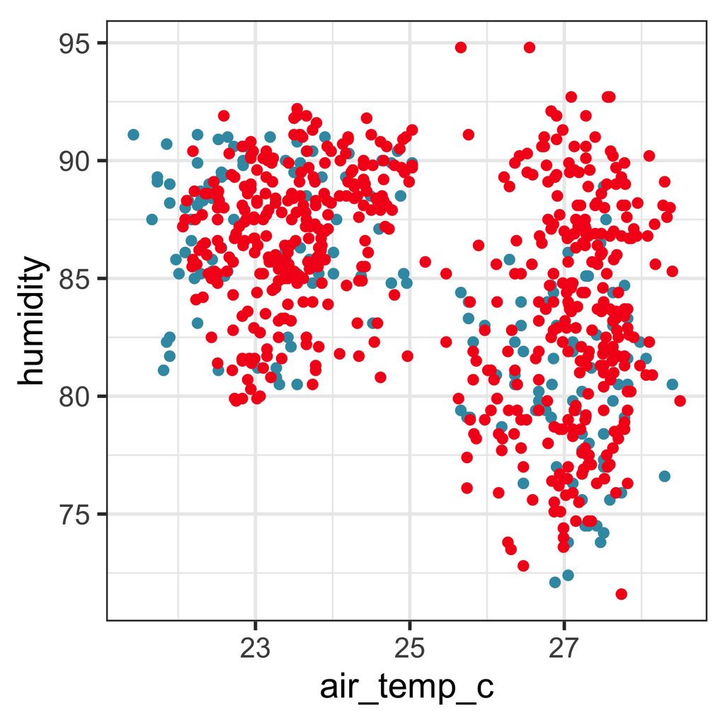

```r
ocean_imp_yr_sim <- nabular(oceanbuoys) |>
  select(air_temp_c, humidity, year) |>
  bind_shadow() |>
  add_label_shadow()

# Need to operate on each subset
ocean_imp_yr_sim_93 <- ocean_imp_yr_sim |>
  filter(year == 1993)
ocean_imp_yr_sim_97 <- ocean_imp_yr_sim |>
  filter(year == 1997)

ocean_imp_yr_sim_93 <- VIM::hotdeck(ocean_imp_yr_sim_93)
ocean_imp_yr_sim_97 <- VIM::hotdeck(ocean_imp_yr_sim_97)

ocean_imp_yr_sim <- bind_rows(ocean_imp_yr_sim_93, ocean_imp_yr_sim_97)

ggplot(ocean_imp_yr_sim,
       aes(x = air_temp_c,
           y = humidity,
           colour = any_missing)) +
  geom_miss_point() +
  scale_color_discrete_divergingx(palette = "Zissou 1") +
  theme(legend.title = element_blank(),
        legend.position = "none")
```

## Networks

## Definition

What do you do if you only receive the association information?

For example, in the Harry Potter series of books, some characters show support and comfort to other characters at different times. (This example is from [Sam Tyner’s geomnet](https://github.com/sctyner/geomnet) which was originally taken from [The Siena Program](https://www.stats.ox.ac.uk/~snijders/siena/siena.html).)

```r
load("../data/hpchars.rda")
glimpse(hp.chars)
```

```
Rows: 64
Columns: 4
$ name       <chr> "Adrian Pucey", "Alicia Spinnet", "Ange…
$ schoolyear <int> 1989, 1989, 1989, 1991, 1991, 1989, 198…
$ gender     <fct> M, F, F, M, M, M, M, F, M, M, M, F, M, …
$ house      <fct> Slytherin, Gryffindor, Gryffindor, Rave…
```

```r
load("../data/hpedges.rda")
glimpse(hp.edges)
```

```
Rows: 434
Columns: 3
$ name1 <chr> "Dean Thomas", "Dean Thomas", "Dean Thomas",…
$ name2 <chr> "Harry James Potter", "Hermione Granger", "N…
$ book  <dbl> 1, 1, 1, 1, 1, 1, 1, 1, 1, 1, 1, 1, 1, 1, 1,…
```

Any data where association between multiple pairs of variables can computed can be examined using networks, and explored using exploratory network analysis.

## Step 1: explore the node data

- school year
- house
- gender

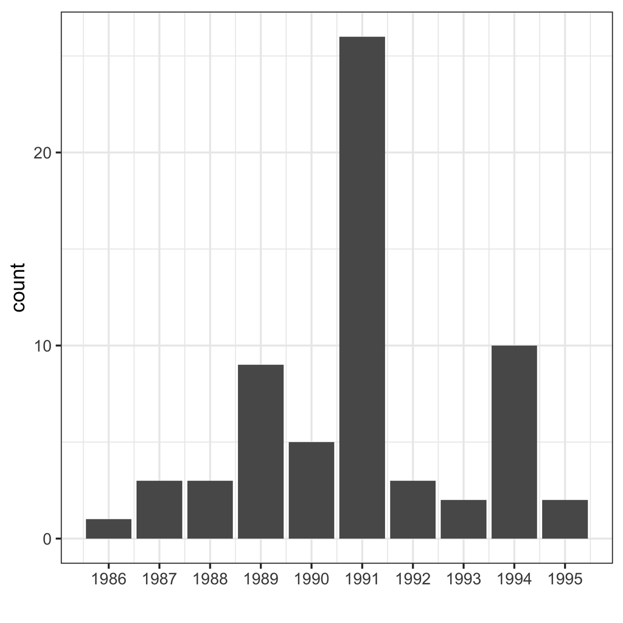

```r
ggplot(hp.chars, aes(x=schoolyear)) +
  geom_bar() +
  scale_x_continuous("", breaks = 1986:1995)
```

What is school year in HP??

[figure not shown]

```r
ggplot(hp.chars, aes(x=house)) +
  geom_bar() +
  xlab("")
```

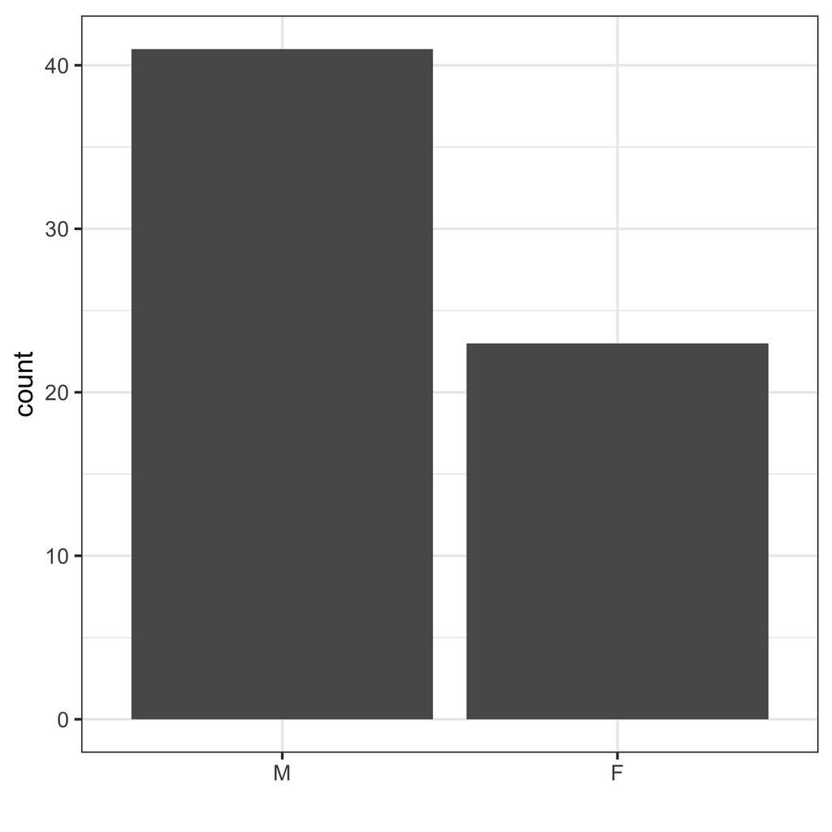

```r
ggplot(hp.chars, aes(x=gender)) +
  geom_bar() +
  xlab("")
```

Is the book lacking in diversity?

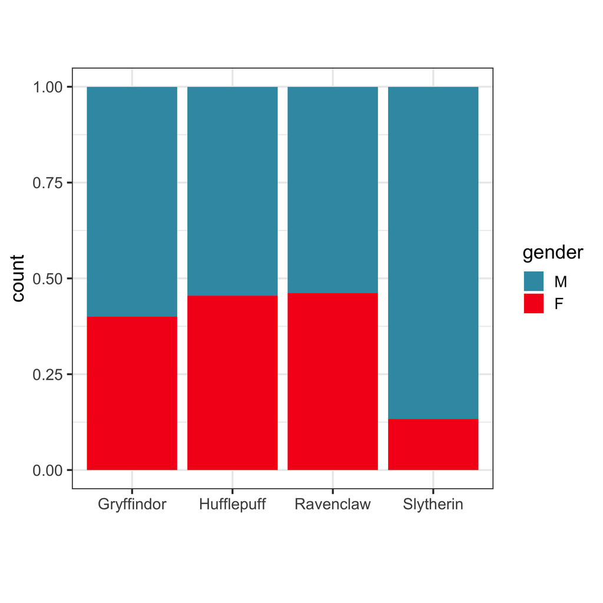

```r
ggplot(hp.chars, aes(x=house, fill=gender)) +
  geom_bar(position="fill") +
  xlab("") +
  scale_fill_discrete_divergingx(palette="Zissou 1")
```

Just Slytherin is lacking diversity.

## Step 2: explore the edge data

[figure not shown]

```r
p1 <- hp.edges |>
  count(name1) |>
  ggplot(aes(x=fct_reorder(name1, n), y=n)) +
  geom_col() +
  xlab("") + ylab("") +
  coord_flip()

p2 <- hp.edges |>
  count(name2) |>
  ggplot(aes(x=fct_reorder(name2, n), y=n)) +
  geom_col() +
  xlab("") + ylab("") +
  coord_flip()
#p1 + p2 + plot_layout(ncol=2)

# Construct data to make plot comparison better
tmp1 <- hp.edges |>
  count(name1) |>
  rename(n1 = n,
         name = name1)
tmp2 <- hp.edges |>
  count(name2) |>
  rename(n2 = n,
         name = name2)
hp.edges_count <- full_join(tmp1, tmp2) |>
  mutate(n1 = if_else(is.na(n1), 0, n1),
         n2 = if_else(is.na(n2), 0, n2)) |>
  mutate(n = n1 + n2)

p1 <- hp.edges_count |>
  ggplot(aes(x=fct_reorder(name, n), y=n1)) +
  geom_col() +
  xlab("") + ylab("") + ggtitle("Name 1") +
  coord_flip() +
  theme(aspect.ratio = 1.5)

p2 <- hp.edges_count |>
  ggplot(aes(x=fct_reorder(name, n), y=n2)) +
  geom_col() +
  xlab("") + ylab("") + ggtitle("Name 2") +
  coord_flip() +
  theme(aspect.ratio = 1.5)

p3 <- hp.edges_count |>
  ggplot(aes(x=fct_reorder(name, n), y=n)) +
  geom_col() +
  xlab("") + ylab("") + ggtitle("Total") +
  coord_flip() +
  theme(aspect.ratio = 1.5)

p1 + p2 + p3 + plot_layout(ncol=3)
```

Similar distribution for who is providing support and who is receiving support. Small differences.

## Step 3: Examine association

```r
library(tidygraph)
library(ggraph)
# Expand edge data
hp.edges_full <- hp.edges |>
  mutate(n = 1) |>
  complete(name1, name2, book, fill = list(n = 0))
# Check
hp.edges_full |> count(name1, name2) -> x
hp.edges_full |> count(name1) -> y
hp.edges_full |> count(name2) -> z
dplyr::full_join(y, z, by=c("name1"="name2")) -> w
# It's missing some items!
name2_miss <- w |>
  filter(is.na(n.y)) |>
  pull(name1)
name1_miss <- w |>
  filter(is.na(n.x)) |>
  pull(name1)
# Ugly manual fix!
n1_d <- hp.edges_full |>
  filter(name2 %in% name1_miss) |>
  rename(name1 = name2,
         name2 = name1) |>
  mutate(n = 0) |>
  select(name1, name2, book, n)
hp.edges_full <- bind_rows(hp.edges_full, n1_d)
n2_d <- hp.edges_full |>
  filter(name1 %in% name2_miss) |>
  rename(name1 = name2,
         name2 = name1) |>
  mutate(n = 0) |>
  select(name1, name2, book, n)
hp.edges_full <- bind_rows(hp.edges_full, n2_d)

he_allbooks_long <- hp.edges_full |>
  group_by(name1, name2) |>
  summarise(n = sum(n))

he_order <- he_allbooks_long |>
  group_by(name1) |>
  summarise(n = sum(n)) |>
  arrange(desc(n))

he_allbooks_long <- he_allbooks_long |>
  mutate(name1 = factor(name1, levels=he_order$name1),
         name2 = factor(name2, levels=he_order$name1))
```

```r
p <- ggplot(he_allbooks_long,
       aes(x=name1,
           y=name2, fill=n)) +
  geom_tile() +
  scale_fill_continuous_sequential(palette="YlGnBu") +
  theme(aspect.ratio=1,
        axis.text = element_blank(),
        axis.ticks = element_blank(),
        legend.position = "none")
ggplotly(p, width=600, height=600)
```

[interactive chart not shown]

## Step 4: Make network summaries

- Process the data
- Network
- Lay out the nodes based on connections over all books
- Set up the data to allow facetting by book, that shows different connections in different books

```r
he_connect <- he_allbooks_long |>
  filter(n > 0) |>
  rename(from = name1, to = name2)
he_graph <- he_connect |> as_tbl_graph()

he_g_plt <- ggraph(he_graph, layout = 'tree', circular=TRUE) +
  geom_edge_link() +
  geom_node_point()

he_nodes <- tibble(x = he_g_plt$data$x,
                   y = he_g_plt$data$y,
                   name = levels(he_allbooks_long$name1))
he_connect <- he_connect |>
  mutate(from_num = as.numeric(from),
         to_num = as.numeric(to))
he_edges <- tibble(
  x = he_g_plt$data$x[he_connect$from_num],
  y = he_g_plt$data$y[he_connect$from_num],
  xend = he_g_plt$data$x[he_connect$to_num],
  yend = he_g_plt$data$y[he_connect$to_num],
  n = he_connect$n
)

# Now set up to facet by book, keeping layout set by
# the overall count
book1 <- hp.edges_full |>
  filter(book == 1, n > 0) |>
  mutate(name1 = factor(name1, levels = he_order$name1),
         name2 = factor(name2, levels = he_order$name1)) |>
  mutate(from_num = as.numeric(name1),
         to_num = as.numeric(name2))

book1_nodes <- he_nodes |>
  mutate(book = 1)
book1_edges <- tibble(
  x = he_g_plt$data$x[book1$from_num],
  y = he_g_plt$data$y[book1$from_num],
  xend = he_g_plt$data$x[book1$to_num],
  yend = he_g_plt$data$y[book1$to_num],
  book = 1
)

book2 <- hp.edges_full |>
  filter(book == 2, n > 0) |>
  mutate(name1 = factor(name1, levels = he_order$name1),
         name2 = factor(name2, levels = he_order$name1)) |>
  mutate(from_num = as.numeric(name1),
         to_num = as.numeric(name2))

book2_nodes <- he_nodes |>
  mutate(book = 2)
book2_edges <- tibble(
  x = he_g_plt$data$x[book2$from_num],
  y = he_g_plt$data$y[book2$from_num],
  xend = he_g_plt$data$x[book2$to_num],
  yend = he_g_plt$data$y[book2$to_num],
  book = 2
)

book3 <- hp.edges_full |>
  filter(book == 3, n > 0) |>
  mutate(name1 = factor(name1, levels = he_order$name1),
         name2 = factor(name2, levels = he_order$name1)) |>
  mutate(from_num = as.numeric(name1),
         to_num = as.numeric(name2))

book3_nodes <- he_nodes |>
  mutate(book = 3)
book3_edges <- tibble(
  x = he_g_plt$data$x[book3$from_num],
  y = he_g_plt$data$y[book3$from_num],
  xend = he_g_plt$data$x[book3$to_num],
  yend = he_g_plt$data$y[book3$to_num],
  book = 3
)

book4 <- hp.edges_full |>
  filter(book == 4, n > 0) |>
  mutate(name1 = factor(name1, levels = he_order$name1),
         name2 = factor(name2, levels = he_order$name1)) |>
  mutate(from_num = as.numeric(name1),
         to_num = as.numeric(name2))

book4_nodes <- he_nodes |>
  mutate(book = 4)
book4_edges <- tibble(
  x = he_g_plt$data$x[book4$from_num],
  y = he_g_plt$data$y[book4$from_num],
  xend = he_g_plt$data$x[book4$to_num],
  yend = he_g_plt$data$y[book4$to_num],
  book = 4
)

book5 <- hp.edges_full |>
  filter(book == 5, n > 0) |>
  mutate(name1 = factor(name1, levels = he_order$name1),
         name2 = factor(name2, levels = he_order$name1)) |>
  mutate(from_num = as.numeric(name1),
         to_num = as.numeric(name2))

book5_nodes <- he_nodes |>
  mutate(book = 5)
book5_edges <- tibble(
  x = he_g_plt$data$x[book5$from_num],
  y = he_g_plt$data$y[book5$from_num],
  xend = he_g_plt$data$x[book5$to_num],
  yend = he_g_plt$data$y[book5$to_num],
  book = 5
)

book6 <- hp.edges_full |>
  filter(book == 6, n > 0) |>
  mutate(name1 = factor(name1, levels = he_order$name1),
         name2 = factor(name2, levels = he_order$name1)) |>
  mutate(from_num = as.numeric(name1),
         to_num = as.numeric(name2))

book6_nodes <- he_nodes |>
  mutate(book = 6)
book6_edges <- tibble(
  x = he_g_plt$data$x[book6$from_num],
  y = he_g_plt$data$y[book6$from_num],
  xend = he_g_plt$data$x[book6$to_num],
  yend = he_g_plt$data$y[book6$to_num],
  book = 6
)

all_books_nodes <- bind_rows(book1_nodes, book2_nodes,
                             book3_nodes, book4_nodes,
                             book5_nodes, book6_nodes)
all_books_edges <- bind_rows(book1_edges, book2_edges,
                           book3_edges, book4_edges,
                           book5_edges, book6_edges)
```

```r
p2 <- ggplot() +
  geom_point(data=all_books_nodes, aes(x=x, y=y, label=name)) +
  geom_segment(data=all_books_edges,
               aes(x=x, y=y, xend=xend, yend=yend),
               linewidth = 0.3) +
  scale_color_viridis_c() +
  facet_wrap(~book, ncol=3) +
  theme(aspect.ratio=1,
        axis.text = element_blank(),
        axis.title = element_blank(),
        axis.ticks = element_blank(),
        panel.background = element_rect(fill=NA,
                                        colour="black"),
        legend.position = "none")
ggplotly(p2, tooltip = "label", width=900, height=600)
```

[interactive chart not shown]

## Key points from today?

- Scatterplots reveal form, strength, and outliers in the relationship between two continuous variables
- Correlation is a single number summary — always look at the plot too, and consider robust measures when the relationship is non-linear or has outliers
- Transformations can linearise a relationship and simplify its description
- Mosaic and double decker plots extend these ideas to categorical variables
- Watch for Simpson’s paradox: check associations within subgroups, not just overall
- Missing values need careful handling — understand *why* they’re missing before imputing
- Networks let us examine association between entities connected by relationships

## Resources

- Unwin (2015) [Graphical Data Analysis with R](http://www.gradaanwr.net)
- Graphics using [ggplot2](https://ggplot2.tidyverse.org)
- Wilke (2019) [Fundamentals of Data Visualization](https://clauswilke.com/dataviz/)
- Friendly and Denis [Milestones in History of Thematic Cartography, Statistical Graphics and Data Visualisation](http://www.datavis.ca/milestones/)
- Tierney et al (2023) [Expanding Tidy Data Principles to Facilitate Missing Data Exploration, Visualization and Assessment of Imputations.](https://doi.org/10.18637/jss.v105.i07)
- Sam Tyner’s exploring network data with [geomnet](https://sctyner.github.io/geomnet/)